CONTENT  
- Estimates for parameters  
- Assumptions  
- Decomposition of the total variation and the $R^2$ statistic  
- Relation Between the Simple and Multiple Regressions  
- Dataset setup  
- Model estimation (Code)  
- Statistical Inference  
- Statistical inference  
- Confidence intervals in code  
- Unbiasedness of the OLS estimator  
- Variance is equal to  
- Normality assumption  
- Using Python for Introductory Econometrics  
- Gauss–Markov Theorem  
- Using an F-Statistic to Test Joint Significance  
- Model diagnostics  
- Summary

Econometrics

Designed by Professor Sasha Shapoval

for New Uzbekistan University

Simple linear regression Multiple Regression OLS Further Issues

Multiple Linear Regression

In this notebook, we study the **multiple linear regression (MLR)** model, which generalizes the simple regression case by allowing several explanatory variables.

We assume the following model:

\begin{equation} y_i = \beta_0 + \beta_1 x_{i1} + \beta_2 x_{i2} + \cdots + \beta_k x_{ik} + u_i, \quad i = 1, \ldots, n. \label{e:mult:regr:mod} \end{equation}

Here:

- $y_i$ — dependent variable (response)
- $x_{ij}$ — explanatory variables (regressors)
- $\beta_j$ — unknown parameters to be estimated
- $u_i$ — random error term

We begin by presenting the **Ordinary Least Squares (OLS) estimator**, including the equations for estimating the regression coefficients, and discuss the conditions under which these estimators are **unbiased** and **efficient**.

The tutorial then covers **inference methods**, such as the construction of **confidence intervals** for coefficients and the use of **t-tests** and **F-tests** for hypothesis testing, allowing for rigorous evaluation of the significance of individual regressors or groups of regressors.

Emphasis is placed on both the theoretical foundations and practical implementation, equipping readers with the tools to estimate, interpret, and test multiple regression models accurately in real-world applications. 🧮

# Estimates for parameters

The Ordinary Least Squares (OLS) estimator minimizes the sum of squared residuals

\begin{equation} \min\limits_{\beta} \ \ S(\boldsymbol{\beta}) = \sum_{i=1}^n (y_i - \beta_0 - \beta_1 x_{i1} - \cdots - \beta_k x_{ik})^2. \label{e:mult:regr:minimizaton} \end{equation}

The solution (in matrix form) is

\begin{equation} \hat{\boldsymbol{\beta}} = (\mathbf{X}'\mathbf{X})^{-1} \mathbf{X}'\mathbf{y}, \label{e:mult:regr:solution} \end{equation}

where $\mathbf{X}$ is the $n \times (k+1)$ matrix of regressors (including a column of ones).

The $i$-th element of $\hat{\boldsymbol{\beta}}$ is denoted by $\hat{\beta}_i$, and it can be written as a linear combination of the observed $y$ values:

$$ \hat{\beta}_i = \sum_{j=1}^n w_{ij} y_j, $$

where the weights come from the $i$-th row of the matrix $(\mathbf{X}'\mathbf{X})^{-1} \mathbf{X}'$:

$$ w_{ij} = \big[(\mathbf{X}'\mathbf{X})^{-1} \mathbf{X}'\big]_{ij}. $$

Thus, each coefficient estimate $\hat{\beta}_i$ is a linear function of the dependent variable $\mathbf{y}$.

# Assumptions

- Zero conditional mean assumption (setting correspondence between \eqref{e:mult:regr:mod} and \eqref{e:mult:regr:minimizaton}:

\begin{equation}  
 E(\mathbf{u} \mid \mathbf{X}) = \mathbf{0}.  
 \label{e:assumption:zero:cond_mean}  
\end{equation}

- The absence of perfect collinearity (allowing for the existence of the solution of \eqref{e:mult:regr:minimizaton}, mind the denominator in \eqref{e:mult:regr:solution}:

\begin{equation}  
 \text{rank}(\mathbf{X}) = k + 1  
 \quad\text{or equivalently}\quad  
 \mathbf{X}'\mathbf{X} \ \text{ is invertible}.  
 \label{e:assumption:non-collinearity}  
\end{equation}

# Decomposition of the total variation and the $R^2$ statistic

This part coincides with that know for a simple regression

In multiple linear regression, we can decompose the total variation in the dependent variable $y_i$ into two parts: the variation **explained by the regression** and the **unexplained variation (residuals)**.

We define three fundamental sums of squares:

- **Total Sum of Squares (SST):** $$ SST = \sum_{i=1}^n (y_i - \bar{y})^2 $$
- **Explained Sum of Squares (SSE):** $$ SSE = \sum_{i=1}^n (\hat{y}_i - \bar{y})^2 $$
- **Residual Sum of Squares (SSR):** $$ SSR = \sum_{i=1}^n (y_i - \hat{y}_i)^2 $$

These quantities satisfy the fundamental identity: $$ SST = SSE + SSR. $$

Coefficient of determination ($R^2$)

The proportion of the total variation in $y$ explained by the regression is measured by the coefficient of determination:

$$ R^2 = \frac{SSE}{SST} = 1 - \frac{SSR}{SST}. $$

Interpretation:

- $R^2 = 1$: perfect fit — all observations lie exactly on the regression surface.
- $R^2 = 0$: the model explains none of the variation in $y$.
- In general, higher $R^2$ indicates better model fit, but adding more regressors will always (weakly) increase $R^2$.

🔹 Adjusted coefficient of determination ($R^2$)

⚠️ **Warning:** $R^2$ always increases (or stays the same) when you add more variables — even if those variables are useless.

To correct this, **adjusted R²** penalizes the addition of irrelevant predictors.

Formula:

$$ R^2_{adj} = 1 - (1 - R^2)\frac{n - 1}{n - p - 1} $$

where

- $n$ = number of observations,
- $p$ = number of predictors (not counting the intercept).

**Example (intuition):**  
If you fit a regression model and get:

- $R^2 = 0.90$
- $R^2_{adj} = 0.82$

→ that means your model explains 90% of the variance, but after accounting for model complexity, the “true” explanatory power is closer to 82%.

# Relation Between the Simple and Multiple Regressions

🔍 Regression with an omitted term

If one relevant variable (say $x_2$) is omitted from the model, the simple regression coefficient $\tilde{\beta}_1$ can be biased. Suppose that $x_2$ is regressed on $x_1$ with the coefficient (slope) $\delta_1$: $x_2 = \delta_0 + \delta_1 x_1 + \text{err}$

Then, when we estimate the simple regression

$$ y_i = \tilde{\beta}_0 + \tilde{\beta}_1 x_{i1} + \text{resid}_i, $$

the estimated coefficient $\tilde{\beta}_1$ reflects both the *direct* effect of $x_1$ on $y$ (through $\beta_1$) and the *indirect* effect through its correlation with $x_2$ (via $\beta_2 \delta_1$).

⚖️ Omitted Variable Bias (OVB)

The expected relationship between the simple and multiple regression coefficients is:

$$ E[\tilde{\beta}_1] = \beta_1 + \beta_2 \delta_1. $$

Thus, if $x_1$ and $x_2$ are correlated ($\delta_1 \neq 0$) and $x_2$ affects $y$ ($\beta_2 \neq 0$), then $\tilde{\beta}_1$ will be **biased** for $\beta_1$.

# Dataset setup

```python
import numpy as np
import pandas as pd

# Example dataset
# Suppose y depends on x1 and x2
data = pd.DataFrame({
    'y': [3.4, 4.2, 5.1, 6.0, 6.8, 7.4, 8.1, 8.8],
    'x1': [1, 2, 3, 4, 5, 6, 7, 8],
    'x2': [2.1, 2.5, 3.0, 3.7, 4.1, 4.8, 5.3, 5.8]
})

data
```

|  | y | x1 | x2 |
| --- | --- | --- | --- |
| 0 | 3.4 | 1 | 2.1 |
| 1 | 4.2 | 2 | 2.5 |
| 2 | 5.1 | 3 | 3.0 |
| 3 | 6.0 | 4 | 3.7 |
| 4 | 6.8 | 5 | 4.1 |
| 5 | 7.4 | 6 | 4.8 |
| 6 | 8.1 | 7 | 5.3 |
| 7 | 8.8 | 8 | 5.8 |

# Model estimation (Code)

```python
import statsmodels.api as sm

# Define regressors and dependent variable
X = data[['x1', 'x2']]
X = sm.add_constant(X)  # adds the intercept term
y = data['y']

# Fit model
model = sm.OLS(y, X).fit()

# Summary
print(model.summary())
```

```
                            OLS Regression Results
==============================================================================
Dep. Variable:                      y   R-squared:                       0.996
Model:                            OLS   Adj. R-squared:                  0.994
Method:                 Least Squares   F-statistic:                     623.3
Date:                Tue, 11 Nov 2025   Prob (F-statistic):           1.01e-06
Time:                        07:28:30   Log-Likelihood:                 6.1410
No. Observations:                   8   AIC:                            -6.282
Df Residuals:                       5   BIC:                            -6.044
Df Model:                           2
Covariance Type:            nonrobust
==============================================================================
                 coef    std err          t      P>|t|      [0.025      0.975]
------------------------------------------------------------------------------
const          3.2949      1.083      3.042      0.029       0.510       6.079
x1             0.9789      0.401      2.441      0.059      -0.052       2.010
x2            -0.3770      0.736     -0.512      0.630      -2.269       1.515
==============================================================================
Omnibus:                        1.108   Durbin-Watson:                   0.767
Prob(Omnibus):                  0.575   Jarque-Bera (JB):                0.758
Skew:                           0.478   Prob(JB):                        0.684
Kurtosis:                       1.833   Cond. No.                         178.
==============================================================================

Notes:
[1] Standard Errors assume that the covariance matrix of the errors is correctly specified.
```

# Statistical Inference

## Statistical inference

From the OLS results, we can obtain:

- Estimated coefficients $\hat{\beta}_j$
- Standard errors $se(\hat{\beta}_j)$
- $t$-statistics: $$ t_j = \frac{\hat{\beta}_j - \beta_{j,0}}{se(\hat{\beta}_j)}, $$ where $\beta_{j,0}$ is the hypothesized value (usually $0$)
- Confidence intervals: $$ \hat{\beta}_j \pm t_{1-\alpha/2, \, n-k-1} \cdot se(\hat{\beta}_j) $$

We can also compute the $R^2$ statistic, F-statistic, and p-values to assess model fit.

## Confidence intervals in code

```python
# Confidence intervals at 95%
alph = 0.05
conf_alpha = model.conf_int(alpha=alph)
print(f'[{alph/2}, {(1-alph/2):.3f}] quantile interval')
conf_alpha.columns = [f'Lower', f'Upper']
conf_alpha
```

```
[0.025, 0.975] quantile interval
```

|  | Lower | Upper |
| --- | --- | --- |
| const | 0.510352 | 6.079424 |
| x1 | -0.051792 | 2.009619 |
| x2 | -2.268677 | 1.514684 |

# Unbiasedness of the OLS estimator

🧩 Key Assumption

The crucial assumption for unbiasedness is the zero conditional mean assumption: $$ E[\mathbf{u} \mid \mathbf{X}] = \mathbf{0}. $$

That is, the error term has zero expected value for every combination of regressors — equivalently, the regressors are **exogenous**.

🧩 Proof

Estimator $$ \begin{equation} \hat{\boldsymbol{\beta}} = (\mathbf{X}'\mathbf{X})^{-1}\mathbf{X}'(\mathbf{X}\boldsymbol{\beta} + \mathbf{u}) = \boldsymbol{\beta} + (\mathbf{X}'\mathbf{X})^{-1}\mathbf{X}'\mathbf{u}. \label{e:mult:est} \end{equation} $$

Take the expectation conditional on $\mathbf{X}$ ($u$ is a random variable):

$$ E[\hat{\boldsymbol{\beta}} \mid \mathbf{X}] = E[\boldsymbol{\beta} + (\mathbf{X}'\mathbf{X})^{-1}\mathbf{X}'\mathbf{u} \mid \mathbf{X}] = \boldsymbol{\beta} + (\mathbf{X}'\mathbf{X})^{-1}\mathbf{X}' \cdot \underbrace{E[\mathbf{u} \mid \mathbf{X}]}_{\text{(assumption) } = 0} = \boldsymbol{\beta}. $$

Taking unconditional expectation (since this holds for any $\mathbf{X}$):

$$ E[\hat{\boldsymbol{\beta}}] = \boldsymbol{\beta}. $$

Hence, **each OLS coefficient** $\hat{\beta}_i$ is an **unbiased estimator** of the true parameter $\beta_i$.

🧠 Intuition

- The estimator $\hat{\boldsymbol{\beta}}$ is the true $\boldsymbol{\beta}$ plus a term that depends on the random errors $\mathbf{u}$.
- If the regressors are uncorrelated with the errors (i.e., $E[\mathbf{u}|\mathbf{X}]=0$), the “noise” term has zero mean.
- Therefore, on average, OLS recovers the true parameters.

$$\newcommand{\Var}{\mathrm{Var}}$$

# Variance is equal to

$$ \Var(\mathbf{u} \mid \mathbf{X}) = \sigma^2 \mathbf{I}_n. $$

🧩 Key Assumption: Homoskedasticity and absence of serial correlation:

$$ \begin{equation} \Var(\hat{\beta}_i \mid \mathbf{X}) = \sigma^2 {\big[ (\mathbf{X}'\mathbf{X})^{-1} \big]}_{ii}. \label{e:mult:var} \end{equation} $$

Proof

Computing the variance of \eqref{e:mult:est}, where only the second term contributes to the variance because $\boldsymbol{\beta}$ is a constant: $$ \Var(\hat{\boldsymbol{\beta}} \mid \mathbf{X}) = \Var\big((\mathbf{X}'\mathbf{X})^{-1}\mathbf{X}'\mathbf{u} \,\big|\, \mathbf{X}\big). $$

Applying the key assumption:

$$ \Var(\hat{\boldsymbol{\beta}} \mid \mathbf{X}) = (\mathbf{X}'\mathbf{X})^{-1}\mathbf{X}' (\sigma^2 \mathbf{I}_n) \mathbf{X} (\mathbf{X}'\mathbf{X})^{-1}. $$$$ = \sigma^2 (\mathbf{X}'\mathbf{X})^{-1}. $$

Therefore, each coefficient $\hat{\beta}_i$ has variance given by the diagonal elements of this matrix. This proves \eqref{e:mult:var}

🧠 Intuition

- The more variation and less multicollinearity in $\mathbf{X}$, the smaller $(\mathbf{X}'\mathbf{X})^{-1}$, and hence the smaller the sampling variance.
- The variance is proportional to the error variance $\sigma^2$ — noisier data → less precise estimates.

🧩 From variance to standard error

In scalar form for multiple regression, we can write:

$$ \operatorname{Var}(\hat{\beta}_1) = \frac{\sigma^2}{SST_{1}(1 - R_1^2)}, $$

so the **standard error** is:

$$ \operatorname{se}(\hat{\beta}_1) = \sqrt{ \frac{\hat{\sigma}^2}{SST_{1}(1 - R_1^2)} }. $$

Where:

- $SST_1 = \sum (x_{1i} - \bar{x}_1)^2$: total variation in $x_1$
- $R_1^2$ is the $R^2$ from regressing $x_1$ on the other regressors
- $\hat{\sigma}^2 = \frac{SSR}{n-k-1}$: estimated variance of the error term

# Normality assumption

🔔 The error term is normally distributed conditional on the regressors:

$$ u_i \mid X \sim \mathcal{N}(0, \sigma^2). $$

This implies that, given the explanatory variables, the disturbances follow a normal distribution with mean zero and constant variance.

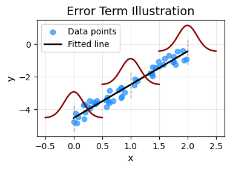

# Using Python for Introductory Econometrics

📈 Example 3.1 from the Wooldridge book:

To install a module type

```
pip3 install modulename
```

(this works for **Google Colab**)  
or with conda

```
conda install -c conda-forge modulename
```

- **conda** installs packages from **conda** channels (e.g., `defaults`, `conda-forge`), not from **PyPI**.
- If the package is not available in **conda**, you can still fall back to pip inside a **conda** environment as with `wooldridge`, when you type

```
pip3 install wooldridge
```

```python
import wooldridge as woo
```

```python
#wooldridge: example 3.1
import wooldridge as woo
import statsmodels.formula.api as smf
gpa1 = woo.dataWoo('gpa1')
reg = smf.ols(formula='colGPA ~ hsGPA + ACT ', data=gpa1)
results = reg.fit()
print(f'results.summary(): \n{results.summary()}\n')
```

```
results.summary():
                            OLS Regression Results
==============================================================================
Dep. Variable:                 colGPA   R-squared:                       0.176
Model:                            OLS   Adj. R-squared:                  0.164
Method:                 Least Squares   F-statistic:                     14.78
Date:                Fri, 21 Nov 2025   Prob (F-statistic):           1.53e-06
Time:                        12:09:06   Log-Likelihood:                -46.573
No. Observations:                 141   AIC:                             99.15
Df Residuals:                     138   BIC:                             108.0
Df Model:                           2
Covariance Type:            nonrobust
==============================================================================
                 coef    std err          t      P>|t|      [0.025      0.975]
------------------------------------------------------------------------------
Intercept      1.2863      0.341      3.774      0.000       0.612       1.960
hsGPA          0.4535      0.096      4.733      0.000       0.264       0.643
ACT            0.0094      0.011      0.875      0.383      -0.012       0.031
==============================================================================
Omnibus:                        3.056   Durbin-Watson:                   1.885
Prob(Omnibus):                  0.217   Jarque-Bera (JB):                2.469
Skew:                           0.199   Prob(JB):                        0.291
Kurtosis:                       2.488   Cond. No.                         298.
==============================================================================

Notes:
[1] Standard Errors assume that the covariance matrix of the errors is correctly specified.
```

**Inspecting the matrix `gpa1`**

```python
import pandas as pd
gpa1.head()
```

|  | age | soph | junior | senior | senior5 | male | campus | business | engineer | colGPA | ... | greek | car | siblings | bgfriend | clubs | skipped | alcohol | gradMI | fathcoll | mothcoll |
| --- | --- | --- | --- | --- | --- | --- | --- | --- | --- | --- | --- | --- | --- | --- | --- | --- | --- | --- | --- | --- | --- |
| 0 | 21 | 0 | 0 | 1 | 0 | 0 | 0 | 1 | 0 | 3.0 | ... | 0 | 1 | 1 | 0 | 0 | 2.0 | 1.0 | 1 | 0 | 0 |
| 1 | 21 | 0 | 0 | 1 | 0 | 0 | 0 | 1 | 0 | 3.4 | ... | 0 | 1 | 0 | 1 | 1 | 0.0 | 1.0 | 1 | 1 | 1 |
| 2 | 20 | 0 | 1 | 0 | 0 | 0 | 0 | 1 | 0 | 3.0 | ... | 0 | 1 | 1 | 0 | 1 | 0.0 | 1.0 | 1 | 1 | 1 |
| 3 | 19 | 1 | 0 | 0 | 0 | 1 | 1 | 1 | 0 | 3.5 | ... | 0 | 0 | 1 | 0 | 0 | 0.0 | 0.0 | 0 | 0 | 0 |
| 4 | 20 | 0 | 1 | 0 | 0 | 0 | 0 | 1 | 0 | 3.6 | ... | 0 | 1 | 1 | 1 | 0 | 0.0 | 1.5 | 1 | 1 | 0 |

5 rows × 29 columns

```python
gpa1.columns
```

```
Index(['age', 'soph', 'junior', 'senior', 'senior5', 'male', 'campus',
       'business', 'engineer', 'colGPA', 'hsGPA', 'ACT', 'job19', 'job20',
       'drive', 'bike', 'walk', 'voluntr', 'PC', 'greek', 'car', 'siblings',
       'bgfriend', 'clubs', 'skipped', 'alcohol', 'gradMI', 'fathcoll',
       'mothcoll'],
      dtype='object')
```

```python
gpa1[['drive', 'bike', 'walk', 'voluntr', 'PC', 'greek', 'car', 'siblings']].head()
```

|  | drive | bike | walk | voluntr | PC | greek | car | siblings |
| --- | --- | --- | --- | --- | --- | --- | --- | --- |
| 0 | 1 | 0 | 0 | 0 | 0 | 0 | 1 | 1 |
| 1 | 1 | 0 | 0 | 0 | 0 | 0 | 1 | 0 |
| 2 | 0 | 0 | 1 | 0 | 0 | 0 | 1 | 1 |
| 3 | 0 | 0 | 1 | 0 | 0 | 0 | 0 | 1 |
| 4 | 0 | 1 | 0 | 0 | 0 | 0 | 1 | 1 |

**Question: Training your skills in running regression Include another regressor, for example 'alcohol', assuming that this is self-reported average number of days per week they drink alcohol. Does the coefficient $\beta_1$ change a lot? How do you interpret the result? Now exclude ACT. What are the changes with $\beta_1$?**

Use:

`reg = smf.ols(formula='colGPA ~ hsGPA + ACT + alcohol', data=gpa1)`  
or  
`reg = smf.ols(formula='colGPA ~ hsGPA', data=gpa1)`

**Problems 3.3**

```python
import wooldridge as woo
import statsmodels.formula.api as smf
sleep75 = woo.dataWoo('sleep75')
sleep75.head()
```

|  | age | black | case | clerical | construc | educ | earns74 | gdhlth | inlf | leis1 | ... | spwrk75 | totwrk | union | worknrm | workscnd | exper | yngkid | yrsmarr | hrwage | agesq |
| --- | --- | --- | --- | --- | --- | --- | --- | --- | --- | --- | --- | --- | --- | --- | --- | --- | --- | --- | --- | --- | --- |
| 0 | 32 | 0 | 1 | 0.0 | 0.0 | 12 | 0.0 | 0 | 1 | 3529 | ... | 0 | 3438 | 0 | 3438 | 0 | 14 | 0 | 13 | 7.070004 | 1024 |
| 1 | 31 | 0 | 2 | 0.0 | 0.0 | 14 | 9500.0 | 1 | 1 | 2140 | ... | 0 | 5020 | 0 | 5020 | 0 | 11 | 0 | 0 | 1.429999 | 961 |
| 2 | 44 | 0 | 3 | 0.0 | 0.0 | 17 | 42500.0 | 1 | 1 | 4595 | ... | 1 | 2815 | 0 | 2815 | 0 | 21 | 0 | 0 | 20.529997 | 1936 |
| 3 | 30 | 0 | 4 | 0.0 | 0.0 | 12 | 42500.0 | 1 | 1 | 3211 | ... | 1 | 3786 | 0 | 3786 | 0 | 12 | 0 | 12 | 9.619998 | 900 |
| 4 | 64 | 0 | 5 | 0.0 | 0.0 | 14 | 2500.0 | 1 | 1 | 4052 | ... | 1 | 2580 | 0 | 2580 | 0 | 44 | 0 | 33 | 2.750000 | 4096 |

5 rows × 34 columns

```python
import wooldridge as woo
import statsmodels.formula.api as smf
sleep75 = woo.dataWoo('sleep75')
reg = smf.ols(formula='sleep ~ totwrk + educ + age', data=sleep75)
results = reg.fit()
print(f'Coefficients: \n{results.params}\n')
```

```
Coefficients:
Intercept    3638.245312
totwrk         -0.148373
educ          -11.133813
age             2.199885
dtype: float64
```

```python
sleep75.columns
```

```
Index(['age', 'black', 'case', 'clerical', 'construc', 'educ', 'earns74',
       'gdhlth', 'inlf', 'leis1', 'leis2', 'leis3', 'smsa', 'lhrwage',
       'lothinc', 'male', 'marr', 'prot', 'rlxall', 'selfe', 'sleep',
       'slpnaps', 'south', 'spsepay', 'spwrk75', 'totwrk', 'union', 'worknrm',
       'workscnd', 'exper', 'yngkid', 'yrsmarr', 'hrwage', 'agesq'],
      dtype='object')
```

# Gauss–Markov Theorem

📈 The **Gauss–Markov assumptions** are:

1. Linearity: the model is linear in parameters.
2. No autocorrelation: errors are uncorrelated.
3. Full rank: $X$ has full column rank $k$.
4. Zero mean errors: $\mathbb{E}[u \, | \, X] = 0$.
5. Homoskedasticity: $\mathrm{Var}(u) = \sigma^2 I_n$.

**Question: Where did we use the full rank assumption? Can we say that the expected value of $u$ is independent on $X$? How do you understand 2?**

Theorem (Gauss–Markov):

Under assumptions 1–5, the ordinary least squares (OLS) estimator

$$ \hat{\beta} = (X^\top X)^{-1} X^\top y $$

is the **Best Linear Unbiased Estimator (BLUE)** of $\beta$.

This means:

- Linear: $\hat{\beta}$ is a linear function of $y$.
- Unbiased: $\mathbb{E}[\hat{\beta}] = \beta$.
- Best: Among all linear unbiased estimators $\tilde{\beta}$,

$$ \mathrm{Var}(\tilde{\beta}) - \mathrm{Var}(\hat{\beta}) \text{ is positive semidefinite.} $$

With, additionally, the normality assumption,

OLS estimators have exact finite-sample distributions:

1. **Estimator distribution:** $$ \hat{\beta}_j \mid X \sim \mathcal{N}\!\left( \beta_j,\; \sigma^2 [(X'X)^{-1}]_{jj} \right). $$
2. **Estimator of error variance:** $$ \hat{\sigma}^2 = \frac{1}{n-k-1} \sum_{i=1}^n \hat{u}_i^2. $$
3. **t-statistics follow a Student t distribution:** $$ t_j = \frac{\hat{\beta}_j - \beta_j} {\sqrt{\hat{\sigma}^2[(X'X)^{-1}]_{jj}}} \sim t_{n-k-1}. $$
4. **F-statistics used for joint hypothesis tests follow an F distribution with $(q,\, n-k-1)$ degrees of freedom.** (to be discussed)

🧩 Testing hypothesis that involves several parameters: $\beta_1 = \beta_2$ against $\beta_1 < \beta_2$: Wooldridge 4.4, database `twoyear`

We will consider a simple model to compare the returns to education at junior colleges and four-year colleges; for simplicity, we refer to the latter as “universities.”  
[Kane and Rouse (1995) provide a detailed analysis of the returns to two- and four-year colleges.]

The population includes working people with a high school degree, and the model is:

$$ \log(\text{wage}) = \beta_0 + \beta_1 \, \text{jc} + \beta_2 \, \text{univ} + \beta_3 \, \text{exper} + u \tag{4.17} $$

where:

- $\text{jc}$ = number of years attending a two-year college
- $\text{univ}$ = number of years at a four-year college
- $\text{exper}$ = months in the workforce

```python
import numpy as np
import wooldridge as woo
import statsmodels.formula.api as smf
twoyear = woo.dataWoo('twoyear')
reg = smf.ols(formula='lwage ~ jc + univ + exper', data=twoyear) #seems that lwage = log(wage)
results = reg.fit()
print("Coefficients:\n", results.params)
print("\nStandard errors:\n", results.bse)
```

```
Coefficients:
 Intercept    1.472326
jc           0.066697
univ         0.076876
exper        0.004944
dtype: float64

Standard errors:
 Intercept    0.021060
jc           0.006829
univ         0.002309
exper        0.000157
dtype: float64
```

```python
def format_regression_output(results):
    """
    Print a statsmodels OLS regression in Stata-style:
    - Model equation with coefficients
    - Coefficients with standard errors underneath
    - t-statistics and p-values
    - Number of observations, SSR, and R-squared
    """

    params = results.params
    ses = results.bse
    t_stats = results.tvalues
    p_values = results.pvalues
    dep_var = results.model.endog_names

    # ----- Build regression equation -----
    eq = f"{dep_var} = "

    # Intercept first (if present)
    if "Intercept" in params.index:
        eq += f"{params['Intercept']:.4f}"
    else:
        eq += "0"

    # Add other variables
    for var in params.index:
        if var == "Intercept":
            continue
        sign = "+" if params[var] >= 0 else "-"
        eq += f" {sign} {abs(params[var]):.4f}*{var}"

    # ----- Print equation -----
    print("Model equation:\n")
    print("  " + eq + "\n")

    # ----- Print coefficients + SEs + t-statistics + p-values -----
    print("Coefficients (standard errors in parentheses, t-statistics and p-values in brackets):\n")
    for var in params.index:
        print(f"{var:12} {params[var]: .4f}")
        print(f"{'':12} ({ses[var]:.4f}) [t={t_stats[var]:.3f}, p={p_values[var]:.3f}]")
    print()

    # ----- Print model statistics -----
    n = int(results.nobs)
    ssr = float((results.resid ** 2).sum())
    r2 = float(results.rsquared)

    print(f"Number of observations (n): {n}")
    print(f"Sum of squared residuals (SSR): {ssr:.4f}")
    print(f"R-squared: {r2:.4f}\n")
```

```python
import wooldridge as woo
import statsmodels.formula.api as smf

twoyear = woo.dataWoo('twoyear')
reg = smf.ols('lwage ~ jc + univ + exper', data=twoyear)
results = reg.fit()

format_regression_output(results)
```

```
Model equation:

  lwage = 1.4723 + 0.0667*jc + 0.0769*univ + 0.0049*exper

Coefficients (standard errors in parentheses, t-statistics and p-values in brackets):

Intercept     1.4723
             (0.0211) [t=69.910, p=0.000]
jc            0.0667
             (0.0068) [t=9.767, p=0.000]
univ          0.0769
             (0.0023) [t=33.298, p=0.000]
exper         0.0049
             (0.0002) [t=31.397, p=0.000]

Number of observations (n): 6763
Sum of squared residuals (SSR): 1250.5435
R-squared: 0.2224
```

To get the standard error of the linear combination

$$ H_0: \beta_{\text{jc}} - \beta_{\text{univ}} = 0 $$

you need the variance of the difference:

$$ \operatorname{Var}(\beta_{\text{jc}} - \beta_{\text{univ}}) = \operatorname{Var}(\beta_{\text{jc}}) + \operatorname{Var}(\beta_{\text{univ}}) - 2\,\operatorname{Cov} (\beta_{\text{jc}}, \beta_{\text{univ}}) $$

Then the standard error is:

$$ se(\beta_{\text{jc}} - \beta_{\text{univ}}) = \sqrt{\operatorname{Var}(\beta_{\text{jc}} - \beta_{\text{univ}})} $$

```python
# covariance matrix of coefficients
cov = results.cov_params()

# extract variances and covariance
var_jc   = cov.loc["jc",   "jc"]
var_univ = cov.loc["univ", "univ"]
cov_jc_univ = cov.loc["jc", "univ"]

# compute standard error of the difference
se_diff = np.sqrt(var_jc + var_univ - 2 * cov_jc_univ)

print("Standard error of (beta_jc - beta_univ):", se_diff)
```

```
Standard error of (beta_jc - beta_univ): 0.006935906572923049
```

```python
#hypothesis testing: t-statistic
beta_diff = results.params["jc"] - results.params["univ"]

t_stat = beta_diff / se_diff

print("beta_jc - beta_univ:", beta_diff)
print("t-statistic:", t_stat)
```

```
beta_jc - beta_univ: -0.010179529521772007
t-statistic: -1.467656666759566
```

```python
#hypothesis testing: t-statistic
import scipy.stats as st
p_value = st.t.cdf(t_stat, df=results.df_resid)   # lower tail
print("One-sided p-value:", p_value)
```

```
One-sided p-value: 0.07112201855247047
```

**Question: Will you reject the null hypothesis at the $5$% significance level?**

No because `p-value` $> 0.05$

# Using an F-Statistic to Test Joint Significance

Consider the following model explaining Major League Baseball players' salaries (Wooldridge):

$$ \begin{multline*} \log(\text{salary}) = \beta_0 + \beta_1 \,\text{years} + \beta_2 \,\text{gamesyr} + \beta_3 \,\text{bavg} \\ + \beta_4 \,\text{hrunsyr} + \beta_5 \,\text{rbisyr} + u, \end{multline*} $$

where:

- **salary**: 1993 total salary
- **years**: years in the league
- **gamesyr**: average games played per year
- **bavg**: career batting average (e.g., 250 means .250)
- **hrunsyr**: home runs per year
- **rbisyr**: runs batted in per year

Suppose we want to test the null hypothesis that, once **years** and **gamesyr** have been controlled for, the performance statistics — **bavg**, **hrunsyr**, and **rbisyr** — have no effect on salary.

In words, the null hypothesis states that productivity, as measured by these baseball statistics, has no effect on salary.

In terms of the model parameters, the null hypothesis is:

$$ H_0:\; \beta_3 = 0, \quad \beta_4 = 0, \quad \beta_5 = 0. $$

```python
import wooldridge as woo
import statsmodels.formula.api as smf

twoyear = woo.dataWoo('mlb1')
reg = smf.ols('lsalary ~ years + gamesyr + bavg + hrunsyr + rbisyr', data=twoyear)
results = reg.fit()

format_regression_output(results)
```

```
Model equation:

  lsalary = 11.1924 + 0.0689*years + 0.0126*gamesyr + 0.0010*bavg + 0.0144*hrunsyr + 0.0108*rbisyr

Coefficients (standard errors in parentheses, t-statistics and p-values in brackets):

Intercept     11.1924
             (0.2888) [t=38.752, p=0.000]
years         0.0689
             (0.0121) [t=5.684, p=0.000]
gamesyr       0.0126
             (0.0026) [t=4.742, p=0.000]
bavg          0.0010
             (0.0011) [t=0.887, p=0.376]
hrunsyr       0.0144
             (0.0161) [t=0.899, p=0.369]
rbisyr        0.0108
             (0.0072) [t=1.500, p=0.134]

Number of observations (n): 353
Sum of squared residuals (SSR): 183.1863
R-squared: 0.6278
```

🧩 Restricted model

The model without the three performance variables (**bavg**, **hrunsyr**, **rbisyr**) is:

$$ \log(\text{salary}) = \beta_0 + \beta_1 \,\text{years} + \beta_2 \,\text{gamesyr} + u $$

where:

- **salary**: 1993 total salary
- **years**: years in the league
- **gamesyr**: average games played per year
- $u$: error term

```python
import wooldridge as woo
import statsmodels.formula.api as smf

twoyear = woo.dataWoo('mlb1')
reg = smf.ols('lsalary ~ years + gamesyr', data=twoyear)
results = reg.fit()

format_regression_output(results)
```

```
Model equation:

  lsalary = 11.2238 + 0.0713*years + 0.0202*gamesyr

Coefficients (standard errors in parentheses, t-statistics and p-values in brackets):

Intercept     11.2238
             (0.1083) [t=103.625, p=0.000]
years         0.0713
             (0.0125) [t=5.703, p=0.000]
gamesyr       0.0202
             (0.0013) [t=15.023, p=0.000]

Number of observations (n): 353
Sum of squared residuals (SSR): 198.3115
R-squared: 0.5971
```

New SSR is grather because the approximation is worse with the smaller number of regressor. How much

**F-Statistic answers**:

Consider the general multiple regression model:

$$ y = \beta_0 + \beta_1 x_1 + \cdots + \beta_k x_k + u \tag{4.34} $$

Suppose we want to test the null hypothesis that a subset of $q$ coefficients are zero:

$$ H_0: \beta_{k-q+1} = 0, \;\; \dots, \;\; \beta_k = 0 \tag{4.35} $$

This imposes $q$ exclusion restrictions on the model. The alternative hypothesis is simply that $H_0$ is false, i.e., at least one of the $q$ coefficients is different from zero.

When we impose these restrictions under $H_0$, we obtain the **restricted model**:

$$ y = \beta_0 + \beta_1 x_1 + \cdots + \beta_{k-q} x_{k-q} + u $$

Let:

- $SSR_R$ = sum of squared residuals from the **restricted model**
- $SSR_U$ = sum of squared residuals from the **unrestricted model**
- $n$ = number of observations
- $q$ = number of restrictions

Then the **F-statistic** for testing $H_0$ is:

$$ F = \frac{(SSR_R - SSR_U)/q}{SSR_U / (n - k - 1)} $$

where $k$ is the total number of regressors in the unrestricted model (excluding the intercept).

If $H_0$ is true, $F$ follows an $F$ distribution with $(q, n-k-1)$ degrees of freedom:

$$ F \sim F_{q, n-k-1} $$

```python
# SSR from unrestricted model (results already fitted)
SSR_U = float(results.ssr)

# Fit the restricted model (excluding bavg, hrunsyr, rbisyr)
reg_restricted = smf.ols('lsalary ~ years + gamesyr', data=twoyear)
res_restricted = reg_restricted.fit()
SSR_R = float(res_restricted.ssr)

# Number of restrictions
q = 3

# Total regressors in unrestricted model (excluding intercept)
k = 5

# Number of observations
n = int(results.nobs)

# Compute F-statistic
F_stat = ((SSR_R - SSR_U)/q) / (SSR_U / (n - k - 1))
print(f"Manual F-statistic: {F_stat:.4f}")
```

[output not shown]

**Using software instead of manual computations**

```python
import wooldridge as woo
import statsmodels.formula.api as smf

twoyear = woo.dataWoo('mlb1')
reg = smf.ols('lsalary ~ years + gamesyr + bavg + hrunsyr + rbisyr', data=twoyear)
results = reg.fit()
# Define the restriction matrix / string
# The variables in your formula: years, gamesyr, bavg, hrunsyr, rbisyr
# beta_3 -> bavg, beta_4 -> hrunsyr, beta_5 -> rbisyr

# Using a string formula for f_test
f_test_result = results.f_test("bavg = 0, hrunsyr = 0, rbisyr = 0")

# Print the F-statistic, p-value, and degrees of freedom
print(f_test_result)
```

```
<F test: F=9.55025271397094, p=4.473712985444251e-06, df_denom=347, df_num=3>
```

The outcome of the joint test may seem surprising given the individual insignificant t-statistics for the three variables. Here is what is happening:

1. **Multicollinearity:**  
   The two variables `hrunsyr` and `rbisyr` are highly correlated. This multicollinearity makes it difficult to uncover the **partial effect** of each variable individually. This is why the individual t-statistics are small.
2. **Joint significance testing:**  
   The F-statistic tests whether the three variables (`bavg`, `hrunsyr`, and `rbisyr`) are **jointly significant**.
3. **Effect of multicollinearity on the F-test:**  
   Multicollinearity between `hrunsyr` and `rbisyr` is much less relevant when testing the joint hypothesis. Therefore, even if the individual t-statistics are insignificant, the F-test can still reject the null hypothesis if the variables together have explanatory power.

**F-statistic** in the output of `results.summary()` is related to the hypothesis

$$ H_0:\, \beta_1 = \beta_2 = \ldots \beta_n = 0 $$

# Model diagnostics

To check the validity of the regression assumptions, we can:

1. Plot residuals versus fitted values (check linearity and homoskedasticity)
2. Examine the distribution of residuals (normality assumption)
3. Compute Variance Inflation Factors (VIFs) to detect multicollinearity

Let's use our first (somewhat artificial) example

```python
import numpy as np
import pandas as pd

# Example dataset
# Suppose y depends on x1 and x2
data = pd.DataFrame({
    'y': [3.4, 4.2, 5.1, 6.0, 6.8, 7.4, 8.1, 8.8],
    'x1': [1, 2, 3, 4, 5, 6, 7, 8],
    'x2': [2.1, 2.5, 3.0, 3.7, 4.1, 4.8, 5.3, 5.8]
})
import statsmodels.api as sm

# Define regressors and dependent variable
X = data[['x1', 'x2']]
X = sm.add_constant(X)  # adds the intercept term
y = data['y']

# Fit model
model = sm.OLS(y, X).fit()
```

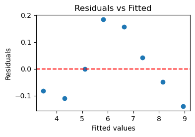

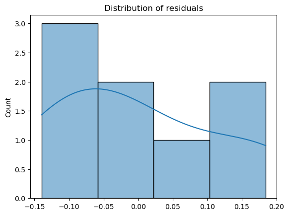

```python
import matplotlib.pyplot as plt
import seaborn as sns

residuals = model.resid
fitted = model.fittedvalues

# Residual plot
fig, ax = plt.subplots(1, 1, figsize=(4, 2.5))
plt.scatter(fitted, residuals)
plt.axhline(y=0, color='red', linestyle='--')
plt.xlabel('Fitted values')
plt.ylabel('Residuals')
plt.title('Residuals vs Fitted')
plt.show()

# Distribution of residuals
sns.histplot(residuals, kde=True)
plt.title('Distribution of residuals')
plt.show()
```

🔍 Detecting multicollinearity: Variance Inflation Factors (VIFs)

Multicollinearity occurs when some explanatory variables are highly linearly correlated.  
This inflates the variances of the estimated coefficients and makes statistical inference unreliable.

To detect multicollinearity, we compute the **Variance Inflation Factor (VIF)** for each regressor:

$$ \mathrm{VIF}_j = \frac{1}{1 - R_j^2}, $$

where $R_j^2$ is the coefficient of determination from regressing variable $x_j$ on all the other explanatory variables.

Interpretation:

- $\mathrm{VIF}_j = 1$: No multicollinearity.
- $\mathrm{VIF}_j > 5$: Moderate multicollinearity.
- $\mathrm{VIF}_j > 10$: Serious multicollinearity concern.

In practice, we compute VIFs for all predictors (excluding the intercept).

```python
from statsmodels.stats.outliers_influence import variance_inflation_factor

# Compute VIFs for each explanatory variable
X_vif = X.drop(columns=['const'])  # exclude intercept if added
vif_data = pd.DataFrame()
vif_data['Variable'] = X_vif.columns
vif_data['VIF'] = [variance_inflation_factor(X_vif.values, i)
                   for i in range(X_vif.shape[1])]

vif_data
```

|  | Variable | VIF |
| --- | --- | --- |
| 0 | x1 | 37.808497 |
| 1 | x2 | 37.808497 |

If any VIF exceeds roughly 10, it suggests serious multicollinearity among the explanatory variables, and you may consider removing or combining variables, or using techniques such as ridge regression.

# Summary

- Multiple regression and its advantage over a simple regression
- Python simulation
- Mathematics: Expected value and variance of the estimator
- Bias and variance with an omitted term
- Gauss-Markov theorem
- Significance of regressors
- Confidence intervals
- Using an F-Statistic to Test Joint Significance
- Model diagnostics

Previous: Simple Linear Regression Next: OLS Further Issues

Course homepage  
Distributed under a Creative Commons Attribution-NonCommercial-ShareAlike 4.0 International (CC BY-NC-SA 4.0) license